# Compositional PCA and differential-abundance analysis

Michael McLaren

2019-08-25

# Setup

```r
library(here)
library(phyloseq)
library(tidyverse)
library(ggbeeswarm)
library(ggthemes)
library(factoextra)
library(cowplot)
library(ALDEx2)
# Custom functions and plot setup
source(here("analysis", "functions-and-ggplot-setup.R"))
```

Set different ggplot theme for this file,

```r
theme_set(theme_minimal() + theme(panel.grid = element_blank()))
color.axis <- "darkgrey"
```

```r
ps <- readRDS(here("results", "ps.Rds"))
# Make variable CD to be our indicator of Cdiff presence for this analysis
sample_data(ps)$CD <- sample_data(ps)$CD_either
# Shorten the sample names
sample_names(ps) <- sample_names(ps) %>%
    str_match("(.+)_") %>%
    .[,2]
sam <- sample_data(ps) %>% as_tibble
tax <- tax_table(ps) %>% as_tibble
```

Restrict our analysis to canine samples that appear in at least 5 samples and at least 100 reads.

```r
filt_fun <- function (x, min_reads = 100, min_samples = 5) {
    (sum(x) > min_reads) & (sum(x > 0) > min_samples)
}
ps.canine <- subset_samples(ps, Host_species == "Canine") %>%
    filter_taxa(filt_fun, prune = TRUE)
```

# CD associations in canines

## Presence/absence testing

Viewing the CLR abundances of the top hits (see below) suggests that the top associations detected by ALDEx2 are driven mainly by differential prevalence (presence/absence), rather than a consistent log-fold change in abundance (which is what ALDEx2 and most other differential abundance methods are designed to measure). We can test for differential prevalence directly with a Fisher’s Exact Test, which we’ll compare to the ALDEx2 associations below.

```r
# Data frame with the prevalence of each taxon (ASV) in CD+ and CD- samples
pa <- ps.canine %>% as_tibble %>%
    group_by(Taxon, CD) %>%
    summarize(
        Absent = sum(Abundance == 0),
        Present = sum(Abundance > 0),
        Prevalence = mean(Abundance > 0)
    ) %>%
    ungroup
# For each ASV, Fisher's exact test of association with CD
pa0 <- pa %>%
    select(-Prevalence) %>%
    group_by(Taxon) %>%
    nest %>%
    mutate(test = map(data, ~fisher.test(.[,2:3]))) %>%
    unnest(map(test, broom::tidy)) %>%
    select(-data, -test)
# Top 10 positive and negative associations
pa0 %>%
    group_by(estimate > 1) %>%
    top_n(10, -p.value) %>%
    arrange(estimate < 1, p.value) %>%
    select(-method,-alternative) %>%
    knitr::kable()
```

| Taxon | estimate | p.value | conf.low | conf.high | estimate > 1 |
| --- | --- | --- | --- | --- | --- |
| ASV82 | Inf | 0.0000000 | 25.0733269 | Inf | TRUE |
| ASV233 | 9.0887159 | 0.0000063 | 3.1651706 | 28.2736129 | TRUE |
| ASV331 | 7.2243177 | 0.0000212 | 2.6149523 | 21.2083338 | TRUE |
| ASV147 | 21.6994532 | 0.0003728 | 2.6900743 | 1002.0020192 | TRUE |
| ASV111 | 4.5478830 | 0.0016073 | 1.6654551 | 12.8957788 | TRUE |
| ASV37 | 4.0376803 | 0.0028759 | 1.5398001 | 11.4167047 | TRUE |
| ASV41 | 6.1512015 | 0.0035371 | 1.5443828 | 29.9444835 | TRUE |
| ASV36 | 3.3838902 | 0.0057073 | 1.3333063 | 8.9547101 | TRUE |
| ASV420 | 5.9805619 | 0.0107851 | 1.2504359 | 38.5845745 | TRUE |
| ASV23 | 3.2914540 | 0.0108817 | 1.2795520 | 8.9930541 | TRUE |
| ASV4 | 0.1665538 | 0.0001090 | 0.0559617 | 0.4506268 | FALSE |
| ASV62 | 0.0000000 | 0.0006006 | 0.0000000 | 0.3712744 | FALSE |
| ASV27 | 0.0868641 | 0.0031160 | 0.0020017 | 0.6001321 | FALSE |
| ASV20 | 0.1865717 | 0.0046419 | 0.0331438 | 0.6941227 | FALSE |
| ASV105 | 0.1557869 | 0.0097654 | 0.0165797 | 0.7109261 | FALSE |
| ASV10 | 0.2963650 | 0.0104011 | 0.0957832 | 0.8175153 | FALSE |
| ASV123 | 0.1090194 | 0.0108429 | 0.0024899 | 0.7670452 | FALSE |
| ASV117 | 0.2254789 | 0.0148848 | 0.0398333 | 0.8479332 | FALSE |
| ASV101 | 0.1183429 | 0.0186688 | 0.0026933 | 0.8395286 | FALSE |
| ASV112 | 0.3315281 | 0.0287436 | 0.1070940 | 0.9162642 | FALSE |

## Aldex

```r
set.seed(20190314)
x <- aldex.clr(otu_table(ps.canine) %>% t,
    sample_data(ps.canine)$CD,
    mc.samples = 128, denom = "all", useMC = TRUE)
x.tt <- aldex.ttest(x, paired.test = FALSE) %>%
    as_tibble(rownames = "Taxon")
x.effect <- aldex.effect(x, useMC = TRUE) %>%
    as_tibble(rownames = "Taxon")
x.all <- left_join(x.tt, x.effect, by = "Taxon")
remove(x.tt, x.effect)
# denom <- getDenom(x) %>%
#     getFeatures(x)[.] %>%
#     names
```

Aldex “MW” plot

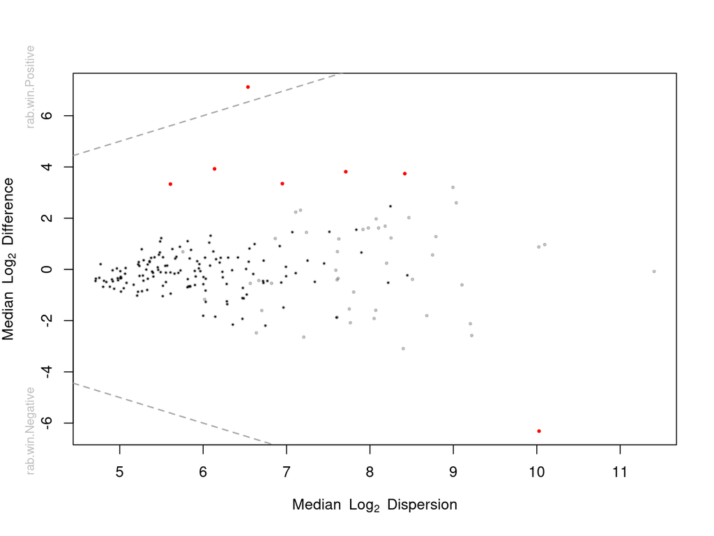

```r
cutoff = 0.1
aldex.plot(x.all, type = "MW", test = "wilcox", cutoff = cutoff)
```

Examine the top positive and negative associations

```r
top_hits <- x.all %>%
    left_join(tax, by = "Taxon") %>%
    group_by(sign(effect)) %>%
    top_n(15, abs(effect)) %>%
    ungroup %>%
    left_join(tax) %>%
    select(Taxon, effect, starts_with("w"), Phylum, Genus) %>%
    arrange(-sign(effect), -abs(effect))
top_hits %>%
    knitr::kable(digits = 3)
```

| Taxon | effect | we.ep | we.eBH | wi.ep | wi.eBH | Phylum | Genus |
| --- | --- | --- | --- | --- | --- | --- | --- |
| ASV82 | 0.932 | 0.000 | 0.002 | 0.000 | 0.001 | Firmicutes | Clostridioides |
| ASV233 | 0.560 | 0.003 | 0.031 | 0.001 | 0.015 | Firmicutes | Anaerostipes |
| ASV331 | 0.521 | 0.004 | 0.041 | 0.001 | 0.017 | Firmicutes | Flavonifractor |
| ASV37 | 0.471 | 0.003 | 0.044 | 0.002 | 0.037 | Firmicutes | Erysipelatoclostridium |
| ASV111 | 0.451 | 0.018 | 0.107 | 0.009 | 0.088 | Firmicutes | NA |
| ASV23 | 0.440 | 0.006 | 0.060 | 0.002 | 0.042 | Firmicutes | Lachnoclostridium |
| ASV36 | 0.351 | 0.050 | 0.231 | 0.045 | 0.253 | Firmicutes | Clostridium_sensu_stricto_1 |
| ASV11 | 0.300 | 0.041 | 0.212 | 0.008 | 0.113 | Firmicutes | NA |
| ASV83 | 0.297 | 0.084 | 0.287 | 0.052 | 0.253 | Firmicutes | Faecalitalea |
| ASV54 | 0.296 | 0.051 | 0.218 | 0.053 | 0.251 | Firmicutes | Terrisporobacter |
| ASV13 | 0.284 | 0.081 | 0.297 | 0.050 | 0.261 | Bacteroidetes | Bacteroides |
| ASV33 | 0.244 | 0.133 | 0.371 | 0.151 | 0.419 | Firmicutes | Romboutsia |
| ASV75 | 0.228 | 0.127 | 0.363 | 0.140 | 0.403 | Firmicutes | Tyzzerella_4 |
| ASV147 | 0.212 | 0.046 | 0.197 | 0.133 | 0.357 | Firmicutes | NA |
| ASV92 | 0.208 | 0.179 | 0.437 | 0.163 | 0.442 | Firmicutes | Blautia |
| ASV4 | -0.637 | 0.000 | 0.005 | 0.000 | 0.011 | Firmicutes | Peptoclostridium |
| ASV10 | -0.367 | 0.012 | 0.106 | 0.016 | 0.132 | Firmicutes | Megamonas |
| ASV20 | -0.349 | 0.004 | 0.045 | 0.021 | 0.136 | Firmicutes | Holdemanella |
| ASV112 | -0.334 | 0.036 | 0.177 | 0.031 | 0.172 | Proteobacteria | Sutterella |
| ASV105 | -0.320 | 0.045 | 0.194 | 0.050 | 0.220 | Firmicutes | Allobaculum |
| ASV62 | -0.315 | 0.006 | 0.041 | 0.044 | 0.171 | Firmicutes | Peptoclostridium |
| ASV7 | -0.304 | 0.037 | 0.209 | 0.054 | 0.279 | Actinobacteria | Collinsella |
| ASV117 | -0.292 | 0.033 | 0.171 | 0.052 | 0.235 | Firmicutes | Blautia |
| ASV27 | -0.288 | 0.008 | 0.068 | 0.041 | 0.192 | Firmicutes | Catenibacterium |
| ASV123 | -0.287 | 0.038 | 0.158 | 0.084 | 0.277 | Firmicutes | Catenibacterium |
| ASV30 | -0.249 | 0.081 | 0.298 | 0.094 | 0.337 | Firmicutes | Faecalibacterium |
| ASV61 | -0.249 | 0.102 | 0.341 | 0.088 | 0.344 | Firmicutes | NA |
| ASV29 | -0.239 | 0.236 | 0.518 | 0.161 | 0.444 | Firmicutes | Coprococcus_3 |
| ASV19 | -0.236 | 0.037 | 0.180 | 0.119 | 0.350 | Firmicutes | Lactobacillus |
| ASV18 | -0.232 | 0.125 | 0.385 | 0.126 | 0.390 | Fusobacteria | Fusobacterium |

Compare the ALDEx2 associations with differential prevalence for the top ALDEx2 hits,

```r
top_hits %>%
    left_join(pa0 %>% select(Taxon, estimate, p.value), by = "Taxon") %>%
    select(-Phylum) %>%
    knitr::kable(digits = 3)
```

| Taxon | effect | we.ep | we.eBH | wi.ep | wi.eBH | Genus | estimate | p.value |
| --- | --- | --- | --- | --- | --- | --- | --- | --- |
| ASV82 | 0.932 | 0.000 | 0.002 | 0.000 | 0.001 | Clostridioides | Inf | 0.000 |
| ASV233 | 0.560 | 0.003 | 0.031 | 0.001 | 0.015 | Anaerostipes | 9.089 | 0.000 |
| ASV331 | 0.521 | 0.004 | 0.041 | 0.001 | 0.017 | Flavonifractor | 7.224 | 0.000 |
| ASV37 | 0.471 | 0.003 | 0.044 | 0.002 | 0.037 | Erysipelatoclostridium | 4.038 | 0.003 |
| ASV111 | 0.451 | 0.018 | 0.107 | 0.009 | 0.088 | NA | 4.548 | 0.002 |
| ASV23 | 0.440 | 0.006 | 0.060 | 0.002 | 0.042 | Lachnoclostridium | 3.291 | 0.011 |
| ASV36 | 0.351 | 0.050 | 0.231 | 0.045 | 0.253 | Clostridium_sensu_stricto_1 | 3.384 | 0.006 |
| ASV11 | 0.300 | 0.041 | 0.212 | 0.008 | 0.113 | NA | 2.008 | 0.236 |
| ASV83 | 0.297 | 0.084 | 0.287 | 0.052 | 0.253 | Faecalitalea | 2.481 | 0.051 |
| ASV54 | 0.296 | 0.051 | 0.218 | 0.053 | 0.251 | Terrisporobacter | 3.245 | 0.015 |
| ASV13 | 0.284 | 0.081 | 0.297 | 0.050 | 0.261 | Bacteroides | 1.972 | 0.141 |
| ASV33 | 0.244 | 0.133 | 0.371 | 0.151 | 0.419 | Romboutsia | 2.431 | 0.046 |
| ASV75 | 0.228 | 0.127 | 0.363 | 0.140 | 0.403 | Tyzzerella_4 | 2.152 | 0.110 |
| ASV147 | 0.212 | 0.046 | 0.197 | 0.133 | 0.357 | NA | 21.699 | 0.000 |
| ASV92 | 0.208 | 0.179 | 0.437 | 0.163 | 0.442 | Blautia | 2.002 | 0.120 |
| ASV4 | -0.637 | 0.000 | 0.005 | 0.000 | 0.011 | Peptoclostridium | 0.167 | 0.000 |
| ASV10 | -0.367 | 0.012 | 0.106 | 0.016 | 0.132 | Megamonas | 0.296 | 0.010 |
| ASV20 | -0.349 | 0.004 | 0.045 | 0.021 | 0.136 | Holdemanella | 0.187 | 0.005 |
| ASV112 | -0.334 | 0.036 | 0.177 | 0.031 | 0.172 | Sutterella | 0.332 | 0.029 |
| ASV105 | -0.320 | 0.045 | 0.194 | 0.050 | 0.220 | Allobaculum | 0.156 | 0.010 |
| ASV62 | -0.315 | 0.006 | 0.041 | 0.044 | 0.171 | Peptoclostridium | 0.000 | 0.001 |
| ASV7 | -0.304 | 0.037 | 0.209 | 0.054 | 0.279 | Collinsella | 0.403 | 0.036 |
| ASV117 | -0.292 | 0.033 | 0.171 | 0.052 | 0.235 | Blautia | 0.225 | 0.015 |
| ASV27 | -0.288 | 0.008 | 0.068 | 0.041 | 0.192 | Catenibacterium | 0.087 | 0.003 |
| ASV123 | -0.287 | 0.038 | 0.158 | 0.084 | 0.277 | Catenibacterium | 0.109 | 0.011 |
| ASV30 | -0.249 | 0.081 | 0.298 | 0.094 | 0.337 | Faecalibacterium | 0.417 | 0.078 |
| ASV61 | -0.249 | 0.102 | 0.341 | 0.088 | 0.344 | NA | 0.426 | 0.059 |
| ASV29 | -0.239 | 0.236 | 0.518 | 0.161 | 0.444 | Coprococcus_3 | 0.389 | 0.054 |
| ASV19 | -0.236 | 0.037 | 0.180 | 0.119 | 0.350 | Lactobacillus | 0.310 | 0.051 |
| ASV18 | -0.232 | 0.125 | 0.385 | 0.126 | 0.390 | Fusobacterium | 0.371 | 0.048 |

The top differentially abundant taxa according to ALDEx2 mainly have p-values < 0.05 by the Fisher test, and in the expected direction. This observation is consistent with the idea that ALDEx2 is mainly picking up presence/absence patterns, which we explore visually below.

```r
# Pick the top 4 positive and negative associations, plus ASV62
taxa <- x.all %>%
    group_by(sign(effect)) %>%
    top_n(4, abs(effect)) %>%
    arrange(-sign(effect), -abs(effect)) %>%
    .$Taxon %>%
    c("ASV62")
clr.post <- getMonteCarloInstances(x) %>%
    map(t) %>%
    map_dfr(~as_tibble(.) %>% mutate(idx = row_number()), .id = "Sample") %>%
    select(Sample, idx, taxa) %>%
    gather("Taxon", "CLR", taxa) %>%
    left_join(sam, by = "Sample") %>%
    left_join(tax, by = "Taxon")
clr.post <- clr.post %>%
    mutate(Taxon = factor(Taxon, taxa))
clr.means <- clr.post %>%
    group_by_at(vars(-idx, -CLR)) %>%
    summarize(CLR = mean(CLR)) %>%
    ungroup
```

Labels for the top taxa by genus and species; use the NCBI organism for C. hiranonis; and only use the first identified species for Silva species id in cases where there are multiple matches.

```r
taxlabs <- tax %>%
    filter(Taxon %in% taxa) %>%
    mutate(
        Species = str_extract(Species, "[^/]+"), # Grab just the first species
        Label = case_when(
            !is.na(NCBI_species) ~ NCBI_species,
            TRUE ~ paste(Genus, Species)
        )
    ) %>%
    mutate(Taxon = factor(Taxon, taxa),
        Label = paste(Taxon, Label, sep = "\n"),
        # Put Genus + species on different lines
        Label = str_replace(Label, " ", "\n"),
        ) %>%
    select(Taxon, Label) %>%
    deframe
taxlabs
```

```
##                                     ASV4
##         "ASV4\n[Clostridium]\nhiranonis"
##                                    ASV10
##           "ASV10\nMegamonas\nfuniformis"
##                                    ASV20
##                "ASV20\nHoldemanella\nNA"
##                                    ASV37
## "ASV37\nErysipelatoclostridium\nramosum"
##                                    ASV62
##        "ASV62\n[Clostridium]\nhiranonis"
##                                    ASV82
##       "ASV82\nClostridioides\ndifficile"
##                                   ASV112
##       "ASV112\nSutterella\nmassiliensis"
##                                   ASV233
##           "ASV233\nAnaerostipes\ncaccae"
##                                   ASV331
##        "ASV331\nFlavonifractor\nplautii"
```

In figure legend, can note that hiranonis is classified as Peptoclostridium (genus) and that ASV112 matches three Sutterella species (massiliensis/stercoricanis/wadsworthensis).

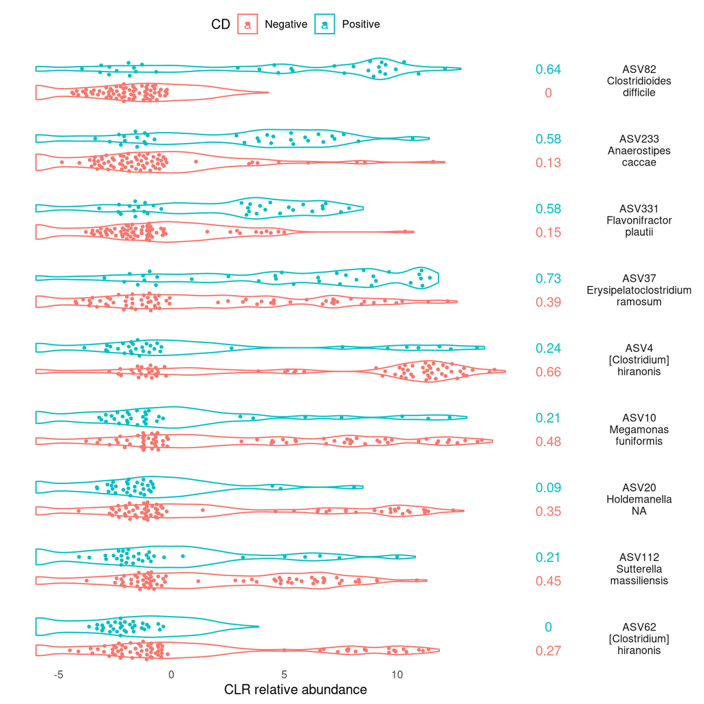

```r
pa1 <- pa %>%
    filter(Taxon %in% taxa) %>%
    mutate(Prevalence = round(Prevalence, 2), Taxon = factor(Taxon, taxa))
p.violin <- clr.post %>%
    filter(idx <= 32) %>%
    ggplot(aes(CD, CLR, color = CD)) +
    # geom_hline(yintercept = 0.4, color = color.axis) +
    # geom_violin(draw_quantiles = c(0.5), bw = 0.5) +
    geom_violin(bw = 0.5) +
    geom_quasirandom(data = clr.means, size = 0.8) +
    scale_y_continuous(limits = c(-6, 17), breaks = c(-5, 0, 5, 10),
        oob = scales::squish) +
    facet_grid(Taxon ~ ., labeller = labeller(Taxon = taxlabs)) +
    coord_flip() +
    geom_text(data = pa1, aes(label = Prevalence), y = 16.7) +
    theme(
        # panel.grid.major.y = element_line(color = color.axis),
        legend.position = "top",
        axis.title.y = element_blank(),
        axis.text.y = element_blank(),
        axis.ticks.y = element_blank(),
        strip.text.y = element_text(angle = 0),
        panel.spacing = unit(1, "lines")
        ) +
    labs(y = "CLR relative abundance")
p.violin
```

It is difficult to tell which points correspond to samples in which the taxon has a read count of 0, since the mean CLR value for a taxon with a read count of 0 depends on the read depth and sample composition. Let’s see what the largest CLR value is for such a taxon.

```r
tb <- clr.means %>%
    select(Sample, Taxon, CD, CLR) %>%
    left_join(otu_table(ps.canine) %>% as_tibble(tidy = TRUE),
        by = c("Sample", "Taxon"))
tb %>%
    filter(Abundance == 0) %>%
    arrange(-CLR)
```

```
## # A tibble: 623 x 5
##    Sample Taxon  CD           CLR Abundance
##    <chr>  <chr>  <fct>      <dbl>     <int>
##  1 CS148  ASV37  Negative -0.0770         0
##  2 CS114  ASV37  Negative -0.0856         0
##  3 CS126  ASV10  Negative -0.148          0
##  4 CS101  ASV62  Negative -0.168          0
##  5 CS101  ASV10  Negative -0.184          0
##  6 CS177  ASV10  Negative -0.199          0
##  7 CS177  ASV82  Negative -0.201          0
##  8 CS126  ASV82  Negative -0.205          0
##  9 CS194  ASV20  Negative -0.209          0
## 10 CS126  ASV233 Negative -0.211          0
## # … with 613 more rows
```

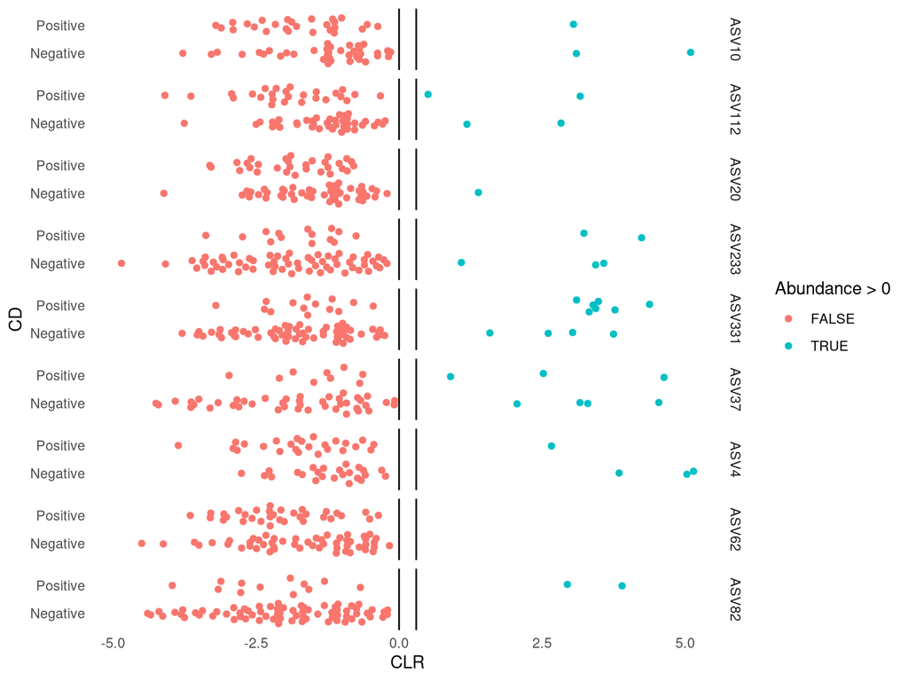

```r
tb %>%
    filter(Abundance <= 10) %>%
    ggplot(aes(CD, CLR, color = Abundance > 0)) +
    facet_grid(Taxon ~ .) +
    geom_hline(yintercept = 0) +
    geom_hline(yintercept = 0.3) +
    geom_quasirandom() +
    coord_flip()
```

# PCA

Weighted pca to give even weight to CD+/- groups

note, weighted pca looks almost identical to the unweighted pca, though the taxa (loadings?) are somewhat larger

```r
# Weight by 1 / # of samples in group
ws <- sample_data(ps.canine) %>%
    as_tibble %>%
    group_by(CD) %>%
    mutate(Weight = 1 / n()) %>%
    ungroup %>%
    select(Sample, Weight) %>%
    deframe
# Weighted pca
pcx.ws <- otu_table(ps.canine) %>%
    transform_sample_counts(function (x) clr(x + 0.5)) %>%
    ade4::dudi.pca(row.w = ws, center = TRUE, scale = FALSE, scannf = FALSE,
    nf = 5)
# Unweighted PCA
pcx <- otu_table(ps.canine) %>%
    transform_sample_counts(function (x) clr(x + 0.5)) %>%
    ade4::dudi.pca(center = TRUE, scale = FALSE, scannf = FALSE,
    nf = 5)
# Percent variance explained
perc_var <- pcx$eig %>%
    {. / sum(.)} %>%
    head(n=5) %>%
    round(., 2) %>%
    {paste0("[", 100 * . , "%]")}
perc_var
```

```
## [1] "[15%]" "[7%]"  "[4%]"  "[4%]"  "[4%]"
```

```r
# Samples plot
pctb.sam <- fviz_pca_ind(pcx) %>%
    .$data %>%
    as_tibble() %>%
    rename(Sample = name, PC1 = x, PC2 = y) %>%
    left_join(sam, by = "Sample")
p1 <- pctb.sam %>%
    ggplot(aes(PC1, PC2, color = CD)) +
    geom_hline(yintercept = 0, color = color.axis) +
    geom_vline(xintercept = 0, color = color.axis) +
    geom_point() +
    theme(legend.position = "bottom") +
    scale_x_continuous(limits = range(pctb.sam$PC1)) +
    scale_y_continuous(limits = range(pctb.sam$PC2)) +
    labs(title = "PCA ordination: Samples",
        x = paste("PC1", perc_var[1]), y = paste("PC2", perc_var[2]))
# Taxa plot
pctb.taxa <- fviz_pca_var(pcx) %>%
    .$data %>%
    as_tibble() %>%
    rename(Taxon = name, PC1 = x, PC2 = y) %>%
    left_join(tax, by = "Taxon") %>%
    left_join(x.all, by = "Taxon")
p2 <- pctb.taxa %>%
    filter(Taxon %in% top_hits$Taxon) %>%
    ggplot(aes(PC1, PC2, label = Taxon, color = as.factor(sign(effect)))) +
    geom_hline(yintercept = 0, color = color.axis) +
    geom_vline(xintercept = 0, color = color.axis) +
    geom_point(aes(size = abs(effect))) +
    ggrepel::geom_text_repel(data = pctb.taxa %>% filter(Taxon %in% taxa)) +
    theme(legend.position = "bottom") +
    scale_x_continuous(limits = range(pctb.sam$PC1)/6) +
    scale_y_continuous(limits = range(pctb.sam$PC2)/6) +
    scale_size(breaks = c(0.3, 0.6, 0.9)) +
    guides(color = guide_legend(override.aes = list(label = ""))) +
    labs(title = "PCA ordination: ASVs (6X zoom)", color = "sign(effect)",
        x = paste("PC1", perc_var[1]), y = paste("PC2", perc_var[2]))
# pctb.taxa %>% filter(wi.ep < 0.05) %>% .$effect %>% abs %>% range
```

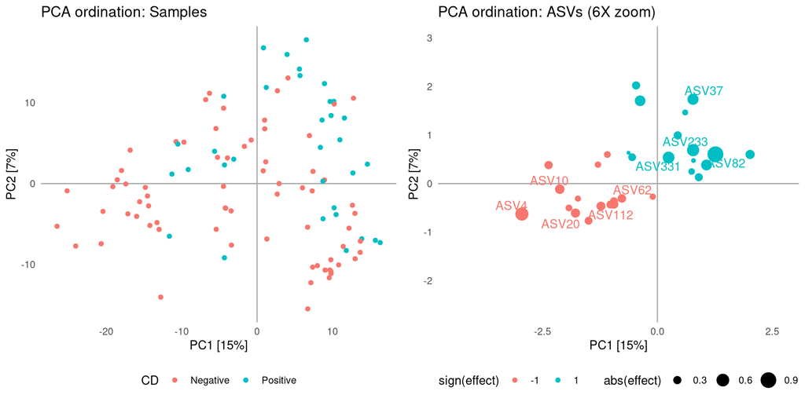

```r
cowplot::plot_grid(
    p1,
    p2,
    align = "h"
)
```

### Possible main text figure

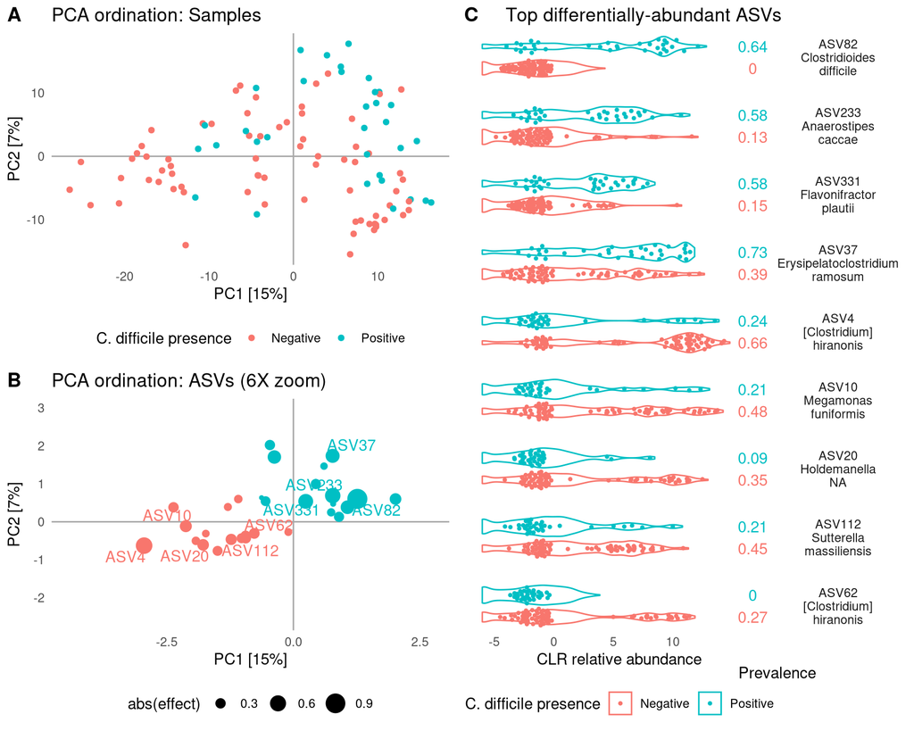

```r
pl <- plot_grid(
    p1 + theme(legend.position = "bottom") +
        labs(color = "C. difficile presence"),
    p2 + theme(legend.position = "bottom") +
        guides(color = FALSE, size = guide_legend()),
    align = "v", ncol = 1,
    labels = c("A", "B")
)
# plot_grid(pl, p.violin, axis = "tb", align = "h")
p <- plot_grid(pl, NULL,
    p.violin +
        theme(legend.position = "bottom") +
        guides(color = guide_legend(override.aes = list(label = ""))) +
        labs(title = "       Top differentially-abundant ASVs",
            x = "Relative abundance (CLR)",
            color = "C. difficile presence"),
    nrow = 1, rel_widths = c(1, 0.0, 1),
    labels = c("", "", "C"), label_x = -0.00
    )
    # draw_text("Prevalence", x = 0.895, y = 0.98, hjust = 1, vjust = 1,
    #     size = 12)
ggdraw(p) +
    draw_text("Prevalence", x = 0.893, y = 0.072, hjust = 1, vjust = 0,
    size = 11)
```

```r
ggsave(here("figures", "community-cd-association.pdf"),
    width = 7, height = 5.5, units = "in", scale = 5/3,
    useDingbats = FALSE)
```